# Generalized additive models in R

We will use `{mgcv}` to fit GAMs, `{gratia}` to inspect and visualize them, and `{ggplot2}` to customize plots. `{mgcv}` includes several fitting functions:

- `gam()` fits generalized additive models.
- `bam()` fits GAMs efficiently to large datasets.
- `gamm()` fits generalized additive mixed models, including random effects and certain residual correlation structures.

`gam()` and `bam()` can also include random effects.

Another package, `{gamm4}`, fits GAMMs using `{lme4}`.

Install the packages below if needed. You only need to install them once.

```r
install.packages(c("mgcv", "gratia", "tidyverse", "broom"))
```

Load the packages for this session.

```r
library(mgcv)
library(gratia)
library(tidyverse)
library(broom)

theme_set(theme_bw(base_size = 12))

ink <- "#0072B2"
```

**Learning objectives:** by the end, you should be able to:

- Explain why a GAM can capture a curved relationship.
- Fit a model containing smooth and categorical effects.
- Distinguish basis dimension from smoothness.
- Interpret smooth plots and generate predictions with uncertainty.
- Identify basic diagnostic problems.

## 1. Prepare data and identify the problem

### Our question

How is juvenile fish growth associated with water temperature, and how does this relationship change after accounting for initial body length and habitat?

We will begin with temperature alone and add the other predictors later. We will use simulated observations from independent fish sampled across a temperature gradient. These are teaching data, not measurements from a real species.

| Variable | Meaning | Units or levels |
| --- | --- | --- |
| `growth` | Growth over a standardized observation period | mm/month |
| `temperature` | Mean water temperature during that period | °C |
| `length_cm` | Initial fish length | cm |
| `habitat` | Habitat category | Seagrass, Sand |

The simulation gives temperature a curved effect, length a linear effect, and habitat an additive difference.

```r
# Set the seed so we all generate the same data
set.seed(316)

# Number of observations
n <- 240

# Create a data frame with three predictors
fish <- data.frame(
  temperature = runif(n, 6, 24),
  length_cm = runif(n, 15, 45),
  habitat = factor(
    sample(c("Seagrass", "Sand"), n, replace = TRUE),
    levels = c("Seagrass", "Sand")
  )
)

# Add simulated growth rates
fish$growth <- 5 +
  6 * exp(-((fish$temperature - 16) / 4)^2) +
  0.05 * (fish$length_cm - 30) +
  ifelse(fish$habitat == "Sand", -1.2, 0) +
  rnorm(n, mean = 0, sd = 0.8)

# Look at the first six rows
head(fish)
```

```
  temperature length_cm  habitat   growth
1    12.00612  36.31837 Seagrass 7.550300
2    19.24091  36.13826 Seagrass 8.440979
3    11.27998  35.58893 Seagrass 6.720868
4    12.59348  40.06997 Seagrass 9.243421
5    11.49929  35.74857 Seagrass 7.878858
6    12.99903  21.32157     Sand 5.692394
```

```r
# Summary statistics
summary(fish)
```

```
  temperature       length_cm         habitat        growth
 Min.   : 6.218   Min.   :15.02   Seagrass:133   Min.   : 1.547
 1st Qu.:11.002   1st Qu.:21.53   Sand    :107   1st Qu.: 5.063
 Median :14.660   Median :30.33                  Median : 6.492
 Mean   :14.877   Mean   :29.72                  Mean   : 6.825
 3rd Qu.:19.340   3rd Qu.:36.79                  3rd Qu.: 8.462
 Max.   :23.919   Max.   :44.97                  Max.   :13.458
```

```r
# Check for missing values
colSums(is.na(fish))
```

```
temperature   length_cm     habitat      growth
          0           0           0           0
```

### Explore the data

The first step when working with new data is to make preliminary plots. Let’s start with a scatterplot.

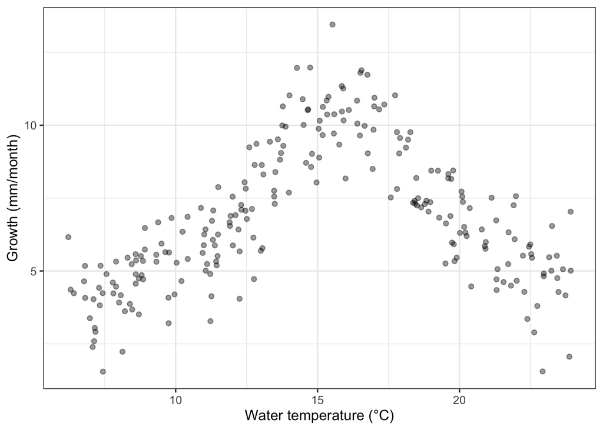

```r
ggplot(fish, aes(x = temperature, y = growth)) +
  geom_point(alpha = 0.4) +
  labs(
    x = "Water temperature (°C)",
    y = "Growth (mm/month)"
  )
```

The plot suggests a nonlinear relationship: growth generally increases toward intermediate temperatures and then decreases at warmer temperatures.

### Fit a linear model

Let’s see what happens if we fit a linear model.

```r
m_lm <- lm(growth ~ temperature, data = fish)

summary(m_lm)
```

```
Call:
lm(formula = growth ~ temperature, data = fish)

Residuals:
    Min      1Q  Median      3Q     Max
-6.0525 -1.6556 -0.3076  1.6711  6.5706

Coefficients:
            Estimate Std. Error t value Pr(>|t|)
(Intercept)  5.38316    0.46967  11.462  < 2e-16 ***
temperature  0.09692    0.02991   3.241  0.00136 **
---
Signif. codes:  0 '***' 0.001 '**' 0.01 '*' 0.05 '.' 0.1 ' ' 1

Residual standard error: 2.33 on 238 degrees of freedom
Multiple R-squared:  0.04226,   Adjusted R-squared:  0.03824
F-statistic:  10.5 on 1 and 238 DF,  p-value: 0.001362
```

Generate predictions at a sequence of temperatures within the observed range. We will use this same prediction grid when plotting the GAM.

```r
new_dat <- tibble(
  temperature = seq(
    min(fish$temperature),
    max(fish$temperature),
    length.out = 200
  )
)

# Predicted mean growth and 95% confidence intervals
preds_lm <- augment(
  m_lm,
  newdata = new_dat,
  interval = "confidence",
  conf.level = 0.95
)

head(preds_lm)
```

```
# A tibble: 6 × 4
  temperature .fitted .lower .upper
        <dbl>   <dbl>  <dbl>  <dbl>
1        6.22    5.99   5.40   6.58
2        6.31    5.99   5.41   6.58
3        6.40    6.00   5.42   6.58
4        6.49    6.01   5.44   6.59
5        6.57    6.02   5.45   6.59
6        6.66    6.03   5.46   6.60
```

`augment()` returns the predicted mean in `.fitted` and the lower and upper confidence limits in `.lower` and `.upper`.

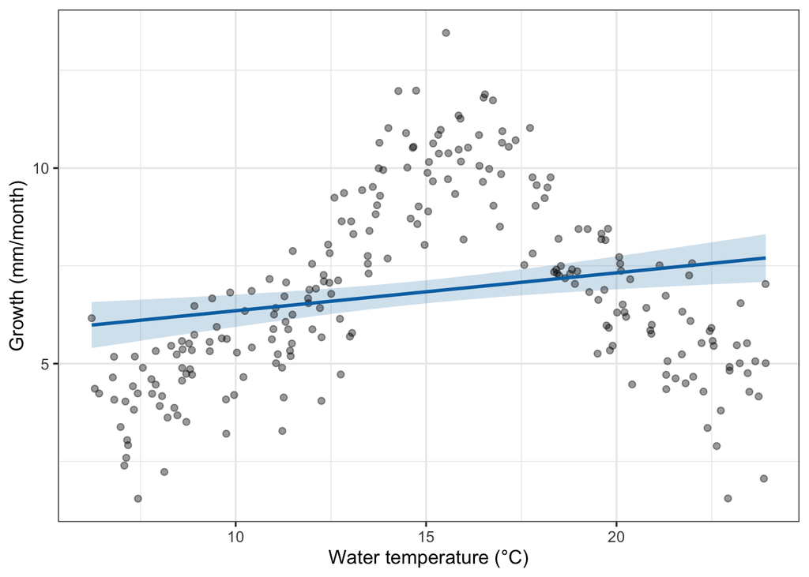

```r
ggplot(fish, aes(x = temperature, y = growth)) +
  geom_ribbon(
    data = preds_lm,
    aes(
      x = temperature,
      ymin = .lower,
      ymax = .upper
    ),
    inherit.aes = FALSE,
    fill = ink,
    alpha = 0.2
  ) +
  geom_point(alpha = 0.4) +
  geom_line(
    data = preds_lm,
    aes(y = .fitted),
    colour = ink,
    linewidth = 1
  ) +
  labs(
    x = "Water temperature (°C)",
    y = "Growth (mm/month)"
  )
```

The linear model estimates a small positive slope. However, this single slope does not capture the curved pattern in the data. The ribbon represents uncertainty in the fitted mean under the linear model; it does not establish that the model describes the relationship appropriately.

Let’s examine the residual plots.

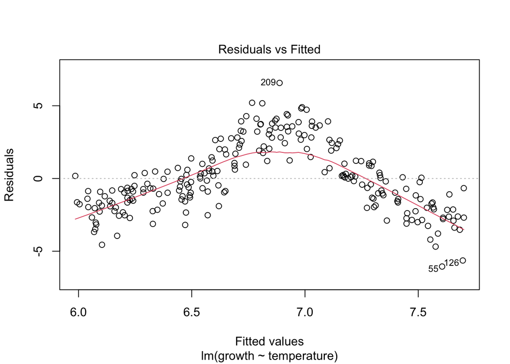

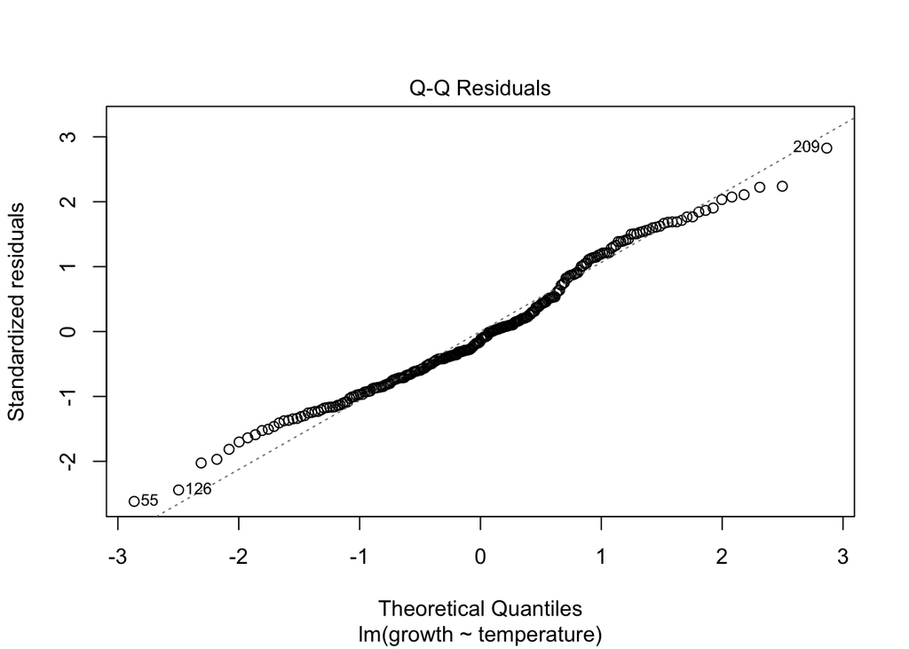

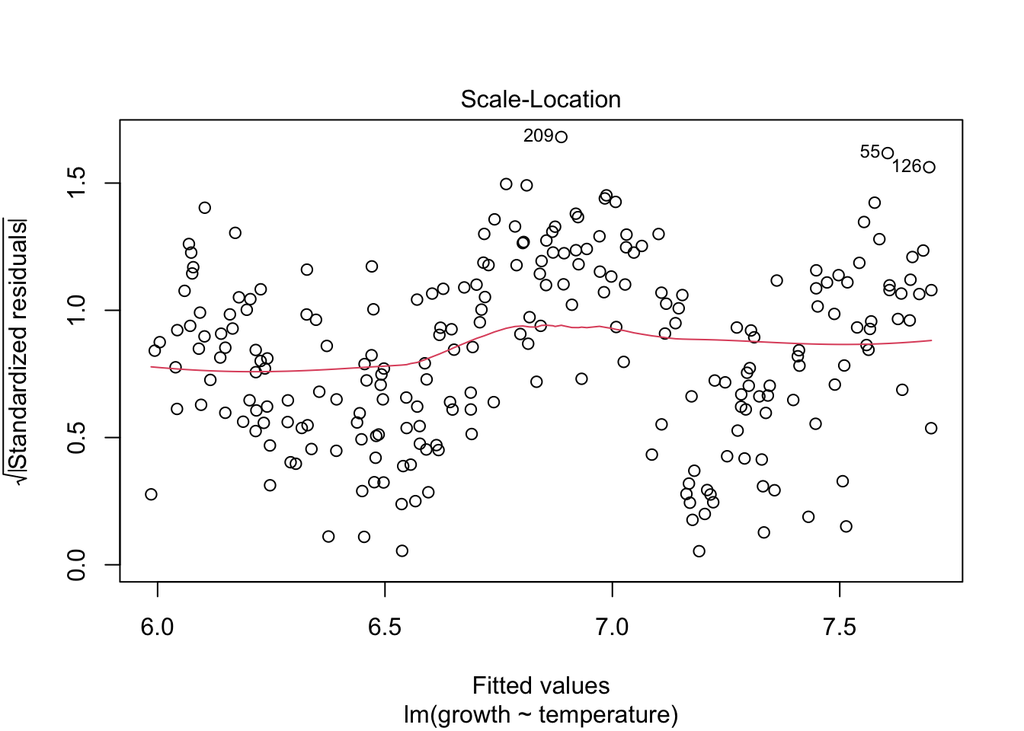

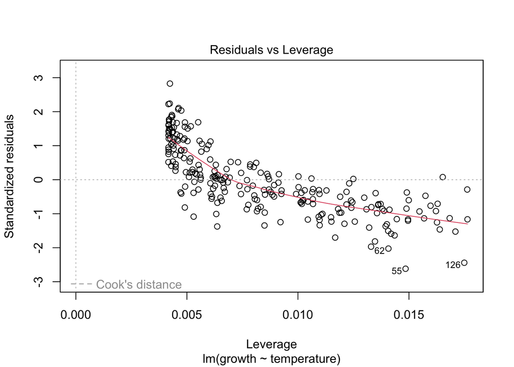

```r
plot(m_lm)
```

The residual-versus-fitted plot shows a systematic pattern: residuals increase and then decrease rather than varying randomly around zero.

Our linear model estimates a constant change in mean growth for each degree of warming. An increase followed by a decrease cannot be summarized well by one slope. A GAM allows us to estimate this curved relationship.

## 2. Fit and understand a first GAM

For a Gaussian response with an identity link, the equation for a one-predictor GAM is:

$$\text{growth}_i =
\beta_0 +
f(\text{temperature}_i) +
\epsilon_i.$$

Here, $f$ is a smooth function estimated from the data. We assume independent, normally distributed errors with constant variance.

A GAM is still a regression model; it allows selected predictor effects to take a flexible shape. Other response distributions and link functions are possible, but we will begin with a Gaussian response and an identity link.

### Fit the model

Fitting a GAM is similar to fitting a linear model: we use `gam()` instead of `lm()` and add `s()` for predictors whose effects we want to estimate as smooth functions.

The argument `k` sets the basis dimension—the number of basis functions available to represent the smooth. This limits its potential complexity. The smoothing penalty controls how much of that flexibility the model uses. We will examine these ideas more closely in Section 3.

```r
m_gam <- gam(
  growth ~ s(temperature, k = 12),
  data = fish,
  method = "REML"
)

summary(m_gam)
```

```
Family: gaussian
Link function: identity

Formula:
growth ~ s(temperature, k = 12)

Parametric coefficients:
            Estimate Std. Error t value Pr(>|t|)
(Intercept)  6.82509    0.07235   94.34   <2e-16 ***
---
Signif. codes:  0 '***' 0.001 '**' 0.01 '*' 0.05 '.' 0.1 ' ' 1

Approximate significance of smooth terms:
                 edf Ref.df     F p-value
s(temperature) 8.276  9.628 86.61  <2e-16 ***
---
Signif. codes:  0 '***' 0.001 '**' 0.01 '*' 0.05 '.' 0.1 ' ' 1

R-sq.(adj) =  0.777   Deviance explained = 78.5%
-REML = 382.16  Scale est. = 1.2562    n = 240
```

In this model:

- `s(temperature)` estimates a smooth temperature effect.
- `k = 12` sets the basis dimension. It does not request 12 bends or 12 effective degrees of freedom.
- `method = "REML"` estimates the smoothing parameter using restricted maximum likelihood.
- With no `family` specified, `gam()` uses a Gaussian response with an identity link.

### Interpret the summary

The GAM summary begins by showing the response distribution, link function, and model formula.

The **parametric coefficients** describe the intercept and any linear or categorical predictor effects. A GAM can combine these effects with smooths. Here, we only have an intercept, representing baseline growth. The temperature smooth adds to or subtracts from this baseline to predict growth at each temperature.

The **approximate significance of the smooth terms** summarizes each smooth’s complexity and tests whether it contributes to explaining the response:

- **`edf` (effective degrees of freedom):** describes the fitted smooth’s complexity. An edf near 1 indicates an approximately straight relationship (and if this is the case for a smooth, revert to linear effect); larger values allow more curvature.
- **`Ref.df` (reference degrees of freedom):** degrees of freedom used in the approximate significance test.
- **`F`:** the test statistic for the smooth. Larger values generally provide stronger evidence of an association.
- **`p-value`:** measures evidence against the hypothesis that the entire smooth is zero. It does not specifically test whether the relationship is nonlinear.

Our temperature smooth has an `edf` of approximately 8.28, indicating a curved relationship, and a very small p-value, providing strong evidence of an association between temperature and growth.

At the bottom of the summary, **deviance explained** is approximately 78.5%. For this Gaussian identity-link model, this corresponds to the proportion of variation explained by the model. **Adjusted R-squared** also accounts for model complexity.

These summaries describe model fit, but we need to plot the fitted relationship to understand its shape.

### Predict and compare the fitted relationships

We will use `fitted_values()` from `{gratia}` to generate predictions at the temperatures in `new_dat`.

This function can return predictions on different scales (response or link). We will just focus on `scale = "response"` , which returns predictions in the original response units—here, growth in mm/month.

```r
preds_gam <- fitted_values(
  m_gam,
  data = new_dat,
  scale = "response"
)

head(preds_gam)
```

```
# A tibble: 6 × 6
   .row temperature .fitted   .se .lower_ci .upper_ci
  <int>       <dbl>   <dbl> <dbl>     <dbl>     <dbl>
1     1        6.22    4.11 0.472      3.19      5.04
2     2        6.31    4.10 0.439      3.24      4.96
3     3        6.40    4.09 0.407      3.29      4.89
4     4        6.49    4.08 0.376      3.34      4.82
5     5        6.57    4.07 0.347      3.39      4.75
6     6        6.66    4.06 0.321      3.43      4.69
```

The predictions are stored in `.fitted`. The output also includes uncertainty estimates, which we will use later.

Let’s compare the GAM and linear model on the same plot. We will omit uncertainty ribbons here to focus on the shapes of the fitted relationships.

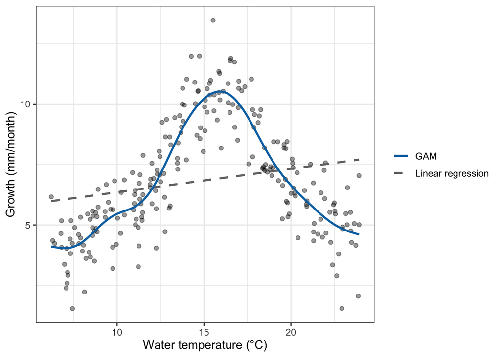

```r
ggplot(fish, aes(x = temperature, y = growth)) +
  geom_point(alpha = 0.4) +
  geom_line(
    data = preds_lm,
    aes(
      y = .fitted,
      linetype = "Linear regression"
    ),
    colour = "grey45",
    linewidth = 1
  ) +
  geom_line(
    data = preds_gam,
    aes(
      y = .fitted,
      linetype = "GAM"
    ),
    colour = ink,
    linewidth = 1
  ) +
  scale_linetype_manual(
    values = c(
      "Linear regression" = "dashed",
      "GAM" = "solid"
    )
  ) +
  labs(
    x = "Water temperature (°C)",
    y = "Growth (mm/month)",
    linetype = NULL
  )
```

The GAM captures the curved relationship: predicted growth increases toward a peak around 16°C, then declines at warmer temperatures. The linear model estimates a small, constant increase in growth with temperature and misses this pattern.

This illustrates how a weak linear trend can conceal a strong nonlinear relationship.

### Check whether `k` provides enough flexibility

We started with `k = 12`. Now we will check whether this provides enough flexibility using `k.check()`.

```r
set.seed(123)
mgcv::k.check(m_gam)
```

```
               k'      edf   k-index p-value
s(temperature) 11 8.276283 0.8944565    0.05
```

A low `k-index` and small `p-value` are warning signs, especially when `edf` is close to `k'`, the maximum available `edf`. These results suggest that residual pattern remains that could reflect insufficient flexibility.

Read the columns as follows:

- **`k'`:** the maximum available `edf` after constraints. For this smooth with `k = 12`, it is 11.
- **`edf`:** the complexity used by the fitted smooth, approximately 8.28 here.
- **`k-index`:** values below 1 suggest residual pattern that could reflect insufficient flexibility.
- **`p-value`:** a small value provides evidence of that residual pattern. It does not establish that `k` is too small, because other model problems can also cause residual structure.

The `p-value` is simulation-based and can vary between runs. A value around 0.05 is a borderline warning rather than a definitive failure.

We can investigate by increasing `k`, refitting the model, and checking whether the estimated curve and diagnostics change appreciably.

```r
# Refit with a larger basis dimension
m_gam24 <- gam(
  growth ~ s(temperature, k = 24),
  data = fish,
  method = "REML"
)

# Compare basis-dimension checks
set.seed(123)
mgcv::k.check(m_gam)
```

```
               k'      edf   k-index p-value
s(temperature) 11 8.276283 0.8944565    0.05
```

```r
set.seed(123)
mgcv::k.check(m_gam24)
```

```
               k'      edf   k-index p-value
s(temperature) 23 9.238387 0.9008891  0.0625
```

```r
# Compare effective degrees of freedom
summary(m_gam)$s.table
```

```
                    edf   Ref.df        F p-value
s(temperature) 8.276283 9.627945 86.60899       0
```

```r
summary(m_gam24)$s.table
```

```
                    edf   Ref.df        F p-value
s(temperature) 9.238387 11.44526 73.28124       0
```

Compare predictions from both models at the same temperatures.

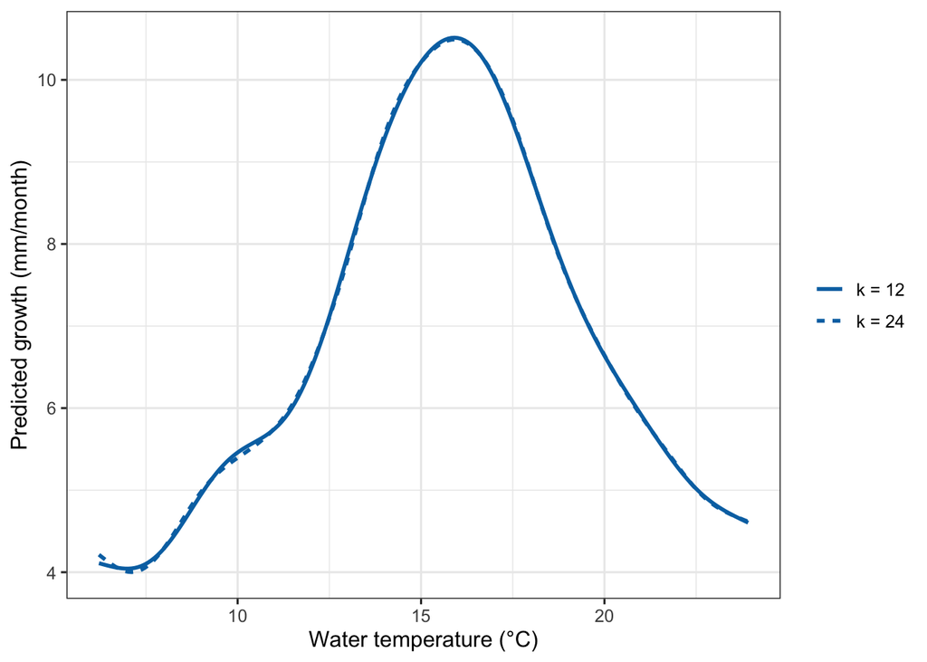

```r
preds_k <- bind_rows(
  fitted_values(
    m_gam,
    data = new_dat,
    scale = "response"
  ) |>
    mutate(model = "k = 12"),

  fitted_values(
    m_gam24,
    data = new_dat,
    scale = "response"
  ) |>
    mutate(model = "k = 24")
)

ggplot(
  preds_k,
  aes(
    x = temperature,
    y = .fitted,
    linetype = model
  )
) +
  geom_line(
    colour = ink,
    linewidth = 1
  ) +
  labs(
    x = "Water temperature (°C)",
    y = "Predicted growth (mm/month)",
    linetype = NULL
  )
```

Increasing `k` from 12 to 24 produces almost identical predictions, suggesting that the original basis dimension was adequate to capture the temperature relationship.

We can also compare AIC values:

```r
AIC(m_gam, m_gam24)
```

```
              df      AIC
m_gam   10.63147 747.6407
m_gam24 11.69428 747.8965
```

Lower AIC indicates better support after accounting for model complexity. A small difference provides little basis for preferring one model. Use this comparison alongside the basis checks and fitted curves.

We will retain the model with the smaller basis dimension (`k = 12`) for subsequent predictions because increasing `k` did not appreciably change the fitted relationship.

## 3. Basis functions, penalties, and `k`

### How can a model estimate a curve?

We have fitted a flexible curve and checked its basis dimension. Now let’s examine how that curve is constructed.

A smooth can be represented as a weighted sum of simpler functions:

$$f(x) = \sum_{j=1}^{K} b_j(x)\beta_j.$$

The $b_j(x)$ are **basis functions**: building blocks whose estimated weights, $\beta_j$, determine the fitted curve. The collection of basis functions is called a **basis**.

A smooth is the curve we estimate by adding together these weighted basis functions.

`basis()` from `{gratia}` extracts the basis functions used by our fitted smooth, and `draw()` displays them.

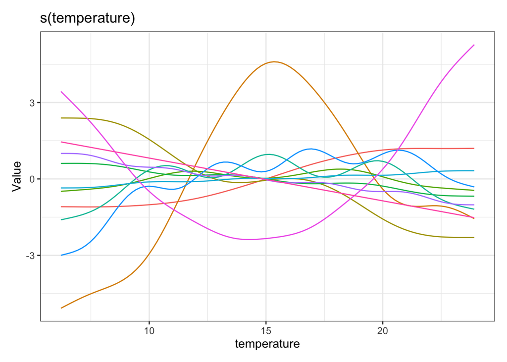

```r
temperature_basis <- basis(
  m_gam,
  select = "s(temperature)"
)

draw(temperature_basis)
```

The plot shows individual basis functions, not their fitted weighted sum. These functions are mathematical building blocks, not separate biological relationships.

Our default `s()` uses a thin-plate regression spline basis. Other spline bases provide different building blocks. We will learn more in the exercises because we will complete part of [Noam Ross’s gam course](https://noamross.github.io/gams-in-r-course). For details about the spline types available in `{mgcv}`, see the [smooth terms documentation](https://stat.ethz.ch/R-manual/R-devel/library/mgcv/html/smooth.terms.html).

The colors in this illustration distinguish the basis functions.

### Enough flexibility, but a penalty for unnecessary wiggles

A flexible curve could follow small fluctuations in the observations rather than the underlying relationship. To limit this, the model uses a **smoothing penalty**.

For our Gaussian model, fitting balances two objectives:

- Fit the observations closely.
- Avoid unnecessary wiggles in the curve.

The **smoothing parameter**, $\lambda$, controls the strength of the penalty. A larger value imposes a stronger penalty and generally produces a smoother curve. A smaller value allows more wiggles.

In our model, restricted maximum likelihood (REML) estimates the smoothing parameter rather than asking us to choose it by eye.

Remember the distinction:

- **`k` sets the available flexibility** by specifying the basis dimension.
- **The smoothing penalty controls how much of that flexibility is used.**

Increasing `k` does not automatically make the fitted curve wigglier.

### Compare different smoothing penalties

Let’s hold the basis dimension fixed and deliberately vary the smoothing parameter using `sp`.

The numerical `sp` values below are specific to this demonstration; they are not recommended defaults.

```r
# Weak penalty
m_weak <- gam(
  growth ~ s(temperature, k = 30),
  data = fish,
  method = "REML",
  sp = 0.00001
)

# Automatically estimated penalty
m_auto <- gam(
  growth ~ s(temperature, k = 30),
  data = fish,
  method = "REML"
)

# Strong penalty
m_strong <- gam(
  growth ~ s(temperature, k = 30),
  data = fish,
  method = "REML",
  sp = 10000
)
```

All three models have the same basis dimension. For `m_weak` and `m_strong`, we fix the smoothing parameter ourselves. For `m_auto`, REML estimates it.

Generate predictions from each model at the same temperatures.

```r
penalty_fits <- bind_rows(
  fitted_values(
    m_weak,
    data = new_dat,
    scale = "response"
  ) |>
    mutate(penalty = "Weak penalty"),

  fitted_values(
    m_auto,
    data = new_dat,
    scale = "response"
  ) |>
    mutate(penalty = "REML-selected penalty"),

  fitted_values(
    m_strong,
    data = new_dat,
    scale = "response"
  ) |>
    mutate(penalty = "Strong penalty")
)
```

Plot the fitted relationships.

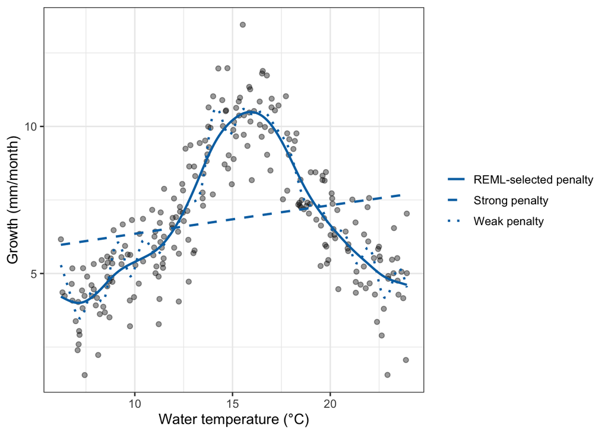

```r
ggplot(fish, aes(x = temperature, y = growth)) +
  geom_point(alpha = 0.4) +
  geom_line(
    data = penalty_fits,
    aes(
      y = .fitted,
      linetype = penalty
    ),
    colour = ink,
    linewidth = 0.9
  ) +
  scale_linetype_manual(
    values = c(
      "Weak penalty" = "dotted",
      "REML-selected penalty" = "solid",
      "Strong penalty" = "dashed"
    )
  ) +
  labs(
    x = "Water temperature (°C)",
    y = "Growth (mm/month)",
    linetype = NULL
  )
```

The weak penalty allows the model to follow more local variation. This does not mean every bend represents a real biological feature. The strong penalty can make the curve too smooth to capture the temperature relationship.

For routine fitting, we omit `sp`, let REML estimate the smoothing parameter, and then check the fitted model.

## 4. Add numeric and categorical predictors

Now address the original question using all three predictors:

$$\text{growth}_i = \beta_0 + f(\text{temperature}_i) + \beta_L\text{length}_{c,i} + \beta_H I(\text{Sand}_i) + \epsilon_i.$$

Center length at 30 cm, a meaningful value within the data. Retain a linear length effect here so students can connect familiar regression coefficients to a GAM.

```r
fish$length_c <- fish$length_cm - 30
m_full <- gam(growth ~ s(temperature, k = 12) + length_c + habitat,
              data = fish, method = "REML")
summary(m_full)
```

```
Family: gaussian
Link function: identity

Formula:
growth ~ s(temperature, k = 12) + length_c + habitat

Parametric coefficients:
             Estimate Std. Error t value Pr(>|t|)
(Intercept)  7.390799   0.073196 100.972  < 2e-16 ***
length_c     0.050307   0.006323   7.956 8.22e-14 ***
habitatSand -1.237209   0.111005 -11.146  < 2e-16 ***
---
Signif. codes:  0 '***' 0.001 '**' 0.01 '*' 0.05 '.' 0.1 ' ' 1

Approximate significance of smooth terms:
                 edf Ref.df     F p-value
s(temperature) 8.771  10.02 149.3  <2e-16 ***
---
Signif. codes:  0 '***' 0.001 '**' 0.01 '*' 0.05 '.' 0.1 ' ' 1

R-sq.(adj) =  0.876   Deviance explained = 88.2%
-REML = 318.05  Scale est. = 0.69741   n = 240
```

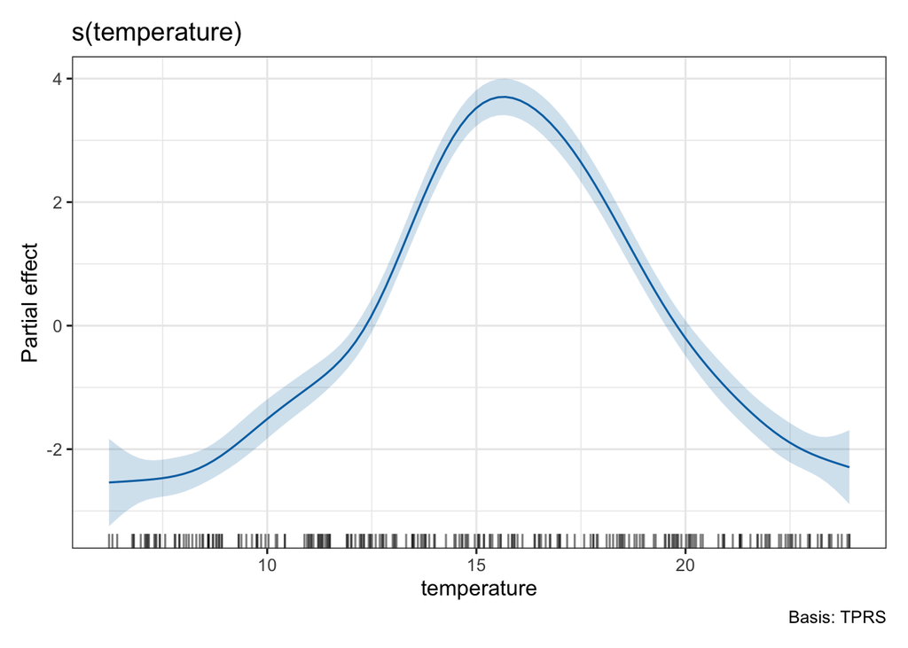

```r
draw(m_full, select = "s(temperature)",
     smooth_col = ink, ci_col = ink,
     overall_uncertainty = FALSE, rug = TRUE)
```

Read the parametric coefficient table separately from the smooth table:

- `length_c` is the estimated change in mean growth, in mm/month, for a 1 cm increase in initial length, holding temperature and habitat constant.
- `habitatSand` is the estimated difference in mean growth between Sand and Seagrass, holding temperature and length constant. Seagrass is the reference level because we set the factor levels explicitly.
- The intercept applies to a 30 cm fish in Seagrass where the centered temperature smooth contributes zero. It is not automatically growth at 0 degrees C or at the mean temperature.

The model is **additive**: the same temperature curve applies in each habitat, and the habitat coefficient shifts that curve vertically. We have not fitted a temperature-by-habitat interaction. The estimated effects describe conditional associations; the model alone does not establish causal effects.

### A second smooth

If length might have a nonlinear relationship with growth, we can estimate it too:

```r
m_two <- gam(growth ~ s(temperature, k = 12) +
               s(length_cm, k = 8) + habitat,
             data = fish, method = "REML")
summary(m_two)
```

```
Family: gaussian
Link function: identity

Formula:
growth ~ s(temperature, k = 12) + s(length_cm, k = 8) + habitat

Parametric coefficients:
            Estimate Std. Error t value Pr(>|t|)
(Intercept)  7.37668    0.07318  100.80   <2e-16 ***
habitatSand -1.23721    0.11100  -11.15   <2e-16 ***
---
Signif. codes:  0 '***' 0.001 '**' 0.01 '*' 0.05 '.' 0.1 ' ' 1

Approximate significance of smooth terms:
                 edf Ref.df      F p-value
s(temperature) 8.771  10.02 149.31  <2e-16 ***
s(length_cm)   1.000   1.00  63.28  <2e-16 ***
---
Signif. codes:  0 '***' 0.001 '**' 0.01 '*' 0.05 '.' 0.1 ' ' 1

R-sq.(adj) =  0.876   Deviance explained = 88.2%
-REML =  315.9  Scale est. = 0.69741   n = 240
```

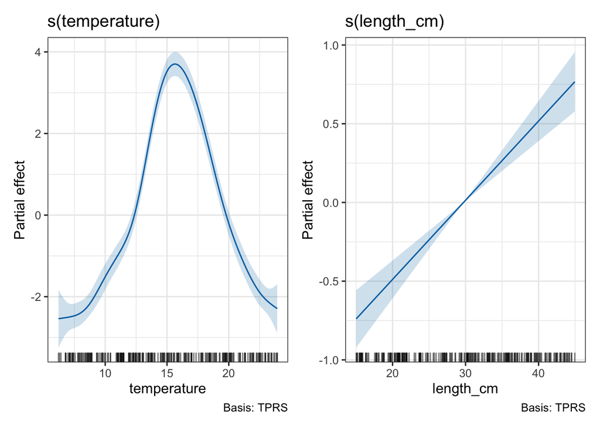

```r
draw(m_two, select = c("s(temperature)", "s(length_cm)"),
     smooth_col = ink, ci_col = ink,
     overall_uncertainty = FALSE, ncol = 2)
```

For these simulated data, an approximately linear length effect would be reasonable. Do not decide that an effect is nonlinear solely because its approximate p-value is small. Continue with `m_full` for the remaining sections.

## 5. Predict and visualize uncertainty

A smooth plot isolates a model component. To obtain predicted growth in mm/month for particular fish, use the full model and a prediction grid containing every predictor the model needs.

Create temperature sequences for both habitats at an initial length of 30 cm. Because `m_full` uses `length_c`, the prediction grid must contain that column.

```r
new_fish <- expand.grid(
  temperature = seq(6, 24, length.out = 200),
  length_c = 0,
  habitat = levels(fish$habitat),
  KEEP.OUT.ATTRS = FALSE,
  stringsAsFactors = FALSE
)
new_fish$habitat <- factor(new_fish$habitat, levels = levels(fish$habitat))

pred_fish <- fitted_values(m_full, data = new_fish,
                          scale = "response", ci_level = 0.95,
                          unconditional = TRUE)
head(pred_fish)
```

```
# A tibble: 6 × 8
   .row temperature length_c habitat  .fitted   .se .lower_ci .upper_ci
  <int>       <dbl>    <dbl> <fct>      <dbl> <dbl>     <dbl>     <dbl>
1     1        6           0 Seagrass    4.84 0.437      3.99      5.70
2     2        6.09        0 Seagrass    4.85 0.409      4.05      5.65
3     3        6.18        0 Seagrass    4.85 0.381      4.10      5.60
4     4        6.27        0 Seagrass    4.85 0.354      4.16      5.55
5     5        6.36        0 Seagrass    4.86 0.327      4.22      5.50
6     6        6.45        0 Seagrass    4.86 0.302      4.27      5.45
```

`fitted_values()` returns the predictor values plus `.fitted`, `.se`, `.lower_ci`, and `.upper_ci`. The leading dots are part of the column names.

`scale = "response"` requests predicted growth in mm/month. For our Gaussian identity-link model, the response and link scales coincide. The default intervals are approximate **95% pointwise intervals for the fitted mean**, not simultaneous bands or prediction intervals for individual fish. `unconditional = TRUE` includes smoothing-parameter uncertainty when available. For other links, `gratia` handles the response-scale transformation of the interval endpoints.

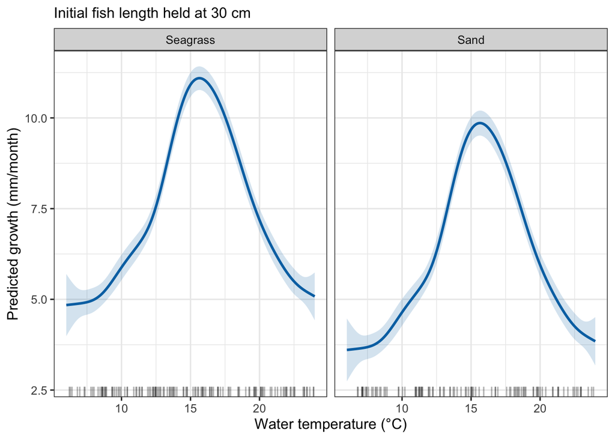

```r
ggplot(pred_fish, aes(x = temperature, y = .fitted)) +
  geom_ribbon(aes(ymin = .lower_ci, ymax = .upper_ci),
              fill = ink, alpha = 0.18) +
  geom_line(colour = ink, linewidth = 1) +
  geom_rug(data = fish, aes(x = temperature),
           inherit.aes = FALSE, alpha = 0.3) +
  facet_wrap(~ habitat) +
  labs(x = "Water temperature (°C)",
       y = "Predicted growth (mm/month)",
       subtitle = "Initial fish length held at 30 cm")
```

We have intentionally omitted raw observations from this plot: predictions condition on length = 30 cm, whereas observed fish have different lengths. The panels share the same y-axis limits so the habitat difference can be compared directly.

## 6. Check the model and revisit `k`

### Diagnose the fitted model

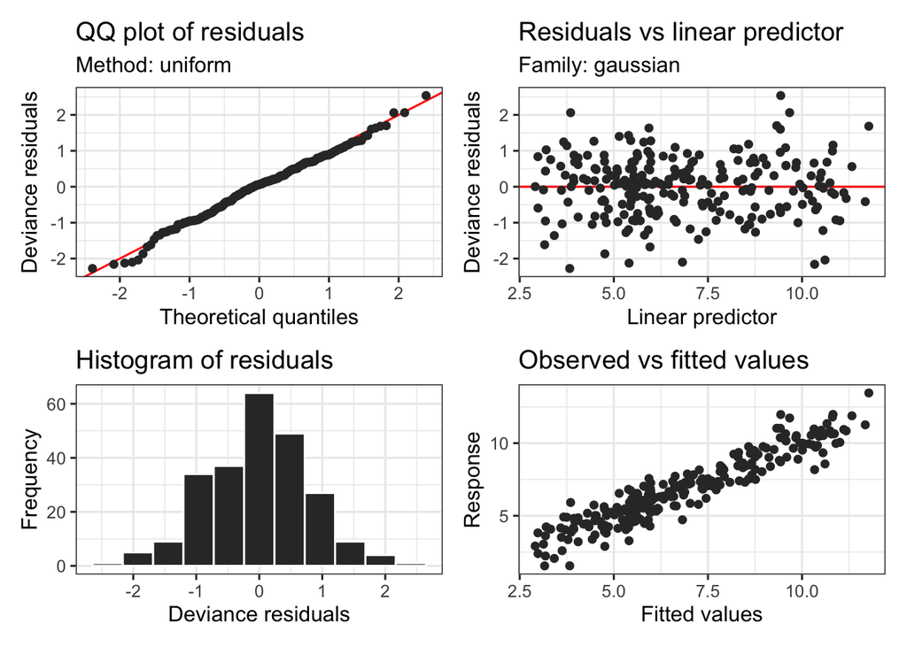

```r
set.seed(316)
appraise(m_full, type = "deviance")
```

```r
# Plot diagnostics and basis checks answer different questions.
# k.check() returns the basis-dimension table without duplicating plots.
set.seed(316)
mgcv::k.check(m_full)
```

```
               k'      edf   k-index p-value
s(temperature) 11 8.770832 0.9874638  0.4225
```

```r
# Inspect optimizer status separately from residual plots.
m_full$converged
```

```
[1] TRUE
```

```r
m_full$outer.info$conv
```

```
[1] "full convergence"
```

For this Gaussian model, inspect the residual Q-Q plot for major departures from normal errors and the residual-versus-fitted plot for remaining patterns or changing variance. The observed-versus-fitted plot describes agreement but is not sufficient by itself. `appraise()` supplies diagnostic plots; it does not replace checks of basis dimension or optimizer status. Here `converged` reports the fitting convergence flag and `outer.info$conv` reports the outer optimizer status for this REML fit. Convergence does not imply that the model is appropriate.

Check residuals against temperature directly. A model can miss a predictor pattern even if the residual-versus-fitted plot is not obviously alarming.

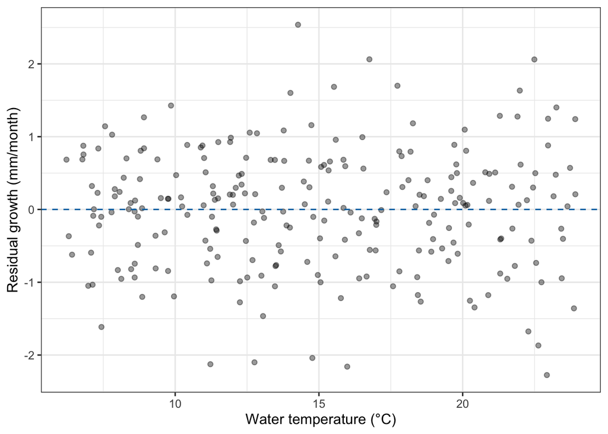

```r
residual_data <- fish
residual_data$residual <- residuals(m_full, type = "response")

ggplot(residual_data, aes(x = temperature, y = residual)) +
  geom_point(alpha = 0.4) +
  geom_hline(yintercept = 0, linetype = "dashed", colour = ink) +
  labs(x = "Water temperature (°C)",
       y = "Residual growth (mm/month)")
```

In the `mgcv::k.check()` basis-dimension table:

- `k'` is the available maximum edf after constraints; for our simple smooth it is usually `k - 1`.
- An edf close to `k'` suggests that available flexibility may be limiting the fit.
- A low k-index and small simulation-based p-value can flag residual pattern consistent with an inadequate basis. They are clues, not automatic instructions: other model problems can also produce residual structure, and the p-value varies between runs.

### Deliberately restrict the basis, then increase it

```r
m_small <- gam(growth ~ s(temperature, k = 4) + length_c + habitat,
               data = fish, method = "REML")
m_large <- gam(growth ~ s(temperature, k = 24) + length_c + habitat,
               data = fish, method = "REML")

set.seed(316)
mgcv::k.check(m_small)
```

```
               k'      edf   k-index p-value
s(temperature)  3 2.981232 0.5199126       0
```

```r
mgcv::k.check(m_full)
```

```
               k'      edf   k-index p-value
s(temperature) 11 8.770832 0.9874638  0.3425
```

```r
mgcv::k.check(m_large)
```

```
               k'      edf   k-index p-value
s(temperature) 23 9.975672 0.9932269  0.4925
```

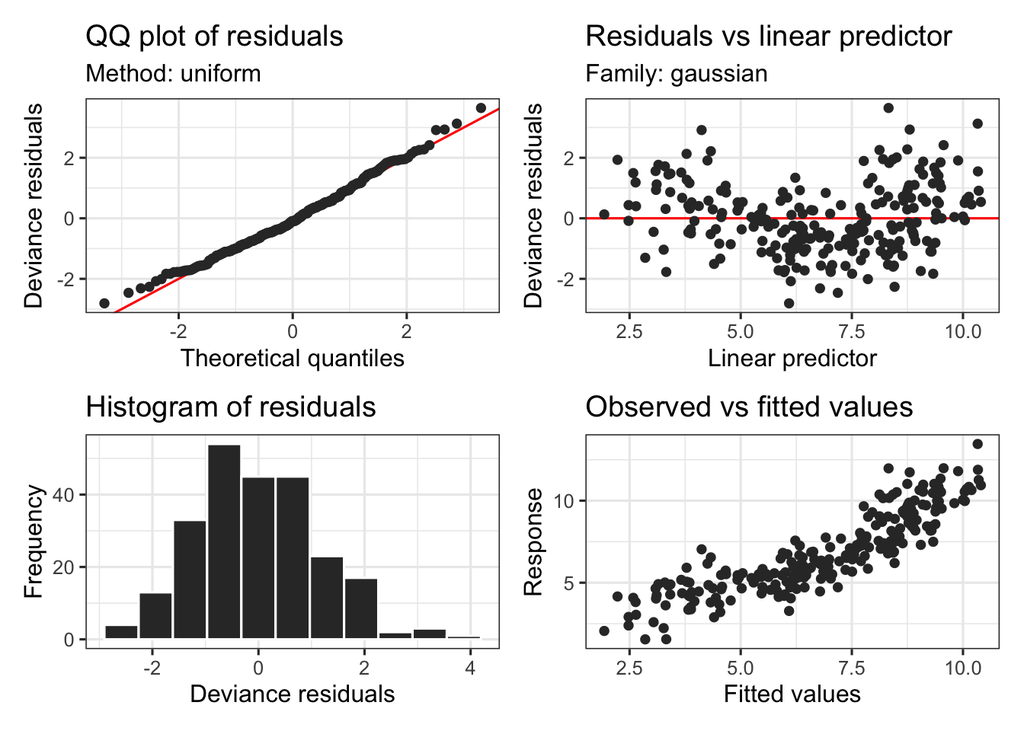

```r
appraise(m_small, type = "deviance")
```

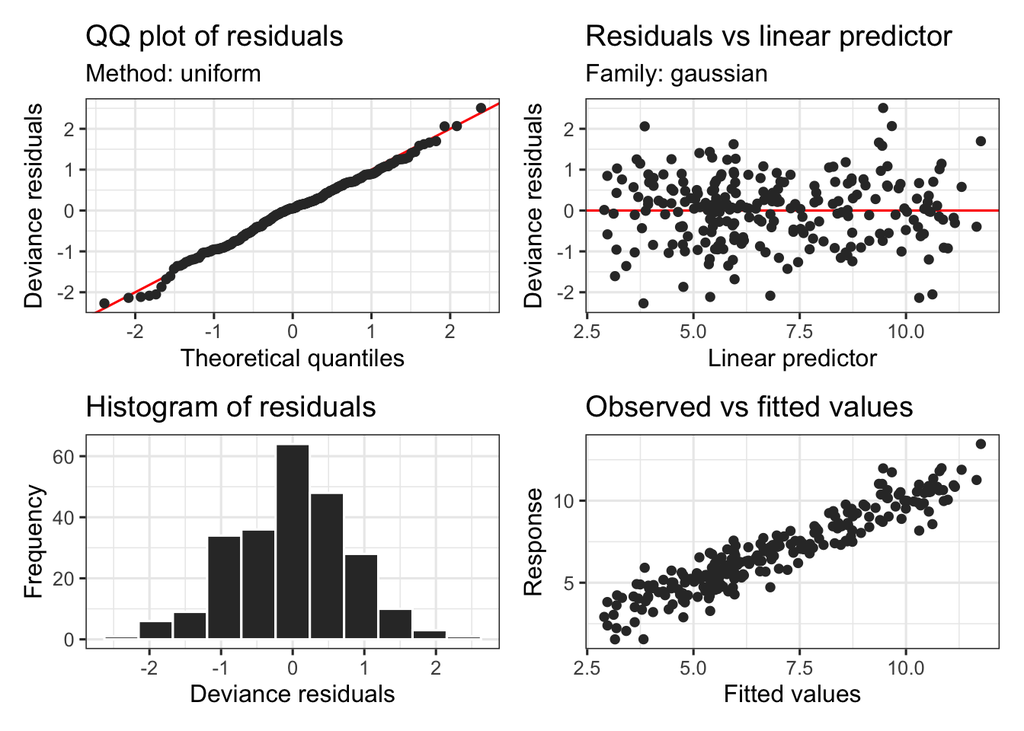

```r
appraise(m_large, type = "deviance")
```

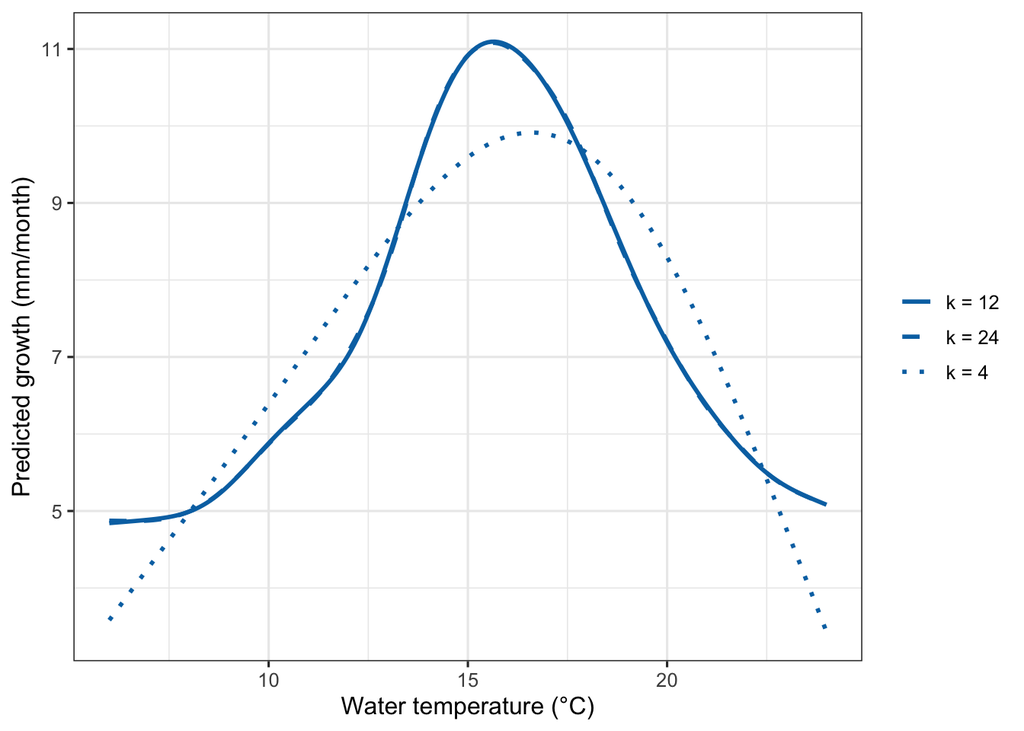

```r
# Compare all three fitted shapes at length = 30 cm in Seagrass.
check_grid <- data.frame(
  temperature = seq(6, 24, length.out = 200),
  length_c = 0,
  habitat = factor("Seagrass", levels = levels(fish$habitat))
)
small_fit <- fitted_values(m_small, data = check_grid)
small_fit$basis_size <- "k = 4"
full_fit <- fitted_values(m_full, data = check_grid)
full_fit$basis_size <- "k = 12"
large_fit <- fitted_values(m_large, data = check_grid)
large_fit$basis_size <- "k = 24"
basis_fits <- rbind(small_fit, full_fit, large_fit)

ggplot(basis_fits, aes(x = temperature, y = .fitted,
                      linetype = basis_size)) +
  geom_line(colour = ink, linewidth = 1) +
  scale_linetype_manual(values = c("k = 4" = "dotted",
                                   "k = 12" = "solid",
                                   "k = 24" = "dashed")) +
  labs(x = "Water temperature (°C)",
       y = "Predicted growth (mm/month)", linetype = NULL)
```

```r
# Is the original k = 12 fit stable when capacity increases?
max(abs(full_fit$.fitted - large_fit$.fitted))
```

```
[1] 0.04240882
```

Increasing `k` should be followed by a refit and a comparison of diagnostics and estimated relationships. We want sufficient capacity and stable conclusions, not the largest possible edf. There is no universal cutoff for an acceptable difference in predictions; judge it in response units and relative to uncertainty.

### Concurvity and dependence

```r
concurvity(m_full, full = TRUE)
```

```
              para s(temperature)
worst    0.4686628    0.094096188
observed 0.4686628    0.003667353
estimate 0.4686628    0.004172093
```

Concurvity is the GAM analogue of collinearity: one model component can be approximated using other components. Values closer to 1 indicate more overlap in the measures reported here. Strong overlap can make separate effects difficult to estimate. There is no universal pass/fail threshold. Our predictors were generated independently, so this is a brief introduction rather than a deliberately problematic example.

These data contain independent fish. Repeated observations of the same fish, spatial clustering, or time-series observations would require additional consideration of dependence. Adding `s(year)` alone does not necessarily remove residual temporal autocorrelation. Likewise, GAM flexibility does not fix an inappropriate response distribution or missing predictors.

## 7. Interpret and communicate results

For these simulated data, describe the temperature curve graphically, interpret the adjusted habitat difference with units, and evaluate uncertainty and diagnostics before drawing conclusions. Avoid causal language and a single temperature slope. Use `summary()` for coefficients and edf, `draw()` for smooth contributions, and `fitted_values()` for predicted mean growth at specified predictor values.

**Discuss together:** How would the analysis change if the response were counts? What additional checks would be needed if every fish were observed repeatedly? Identify these as next steps; you do not need to fit those models today.

### Independent practice after the guided tutorial

Spend about 60 minutes working through [Noam Ross’s Chapter 1](https://noamross.github.io/gams-in-r-course/chapter1/) and [Chapter 2](https://noamross.github.io/gams-in-r-course/chapter2/). Finish those chapters afterward if needed; later chapters are not assigned. Ross may use different plotting functions, but the underlying GAM ideas are the same.

### Take-home workflow

1. Plot the data and state the question.
2. Decide which effects need flexibility and which can remain linear or categorical.
3. Fit the GAM with a suitable response family and smoothness-selection method.
4. Interpret smooths graphically and parametric terms with units.
5. Predict for explicitly defined covariate values and label uncertainty correctly.
6. Check convergence, residuals, basis adequacy, and relevant dependence before drawing conclusions.

### Optional extensions (not assigned today)

- Fit a Poisson or negative-binomial GAM for counts; assess dispersion and use the appropriate link.
- Allow habitat-specific temperature curves with `habitat + s(temperature, by = habitat)`; this requires enough observations over the temperature range in each habitat.
- Explore held-out prediction and validation that respect any spatial, temporal, or individual grouping.

## Sources and further learning

This is an original teaching sequence with newly written explanations and a reproducible simulated example. It combines the introductory topics below rather than reproducing their text, slides, or exercises. Source links also provide deeper explanations beyond this short class.

| Resource | Connection to this tutorial |
| --- | --- |
| [Noam Ross, GAMs in R — Chapter 1](https://noamross.github.io/gams-in-r-course/chapter1/) | Linear-to-smooth progression; basis functions; complexity and penalties; multiple predictors. |
| [Noam Ross, GAMs in R — Chapter 2](https://noamross.github.io/gams-in-r-course/chapter2/) | Interpreting smooths, uncertainty, model checking, and concurvity. |
| [Michael Clark, Introduction to GAMs](https://m-clark.github.io/generalized-additive-models/introduction.html) | Connecting familiar regression to nonlinear predictor effects. |
| [Simon Wood, mgcv: gam](https://stat.ethz.ch/R-manual/R-devel/library/mgcv/html/gam.html) | Model specification and smoothness selection. |
| [Simon Wood, mgcv: choose.k](https://stat.ethz.ch/R-manual/R-devel/library/mgcv/html/choose.k.html) | Distinguishing basis dimension from penalization and checking an increased basis. |
| [Simon Wood, mgcv: predict.gam](https://stat.ethz.ch/R-manual/R-devel/library/mgcv/html/predict.gam.html) | Prediction scales, standard errors, and smoothing-parameter uncertainty. |
| [Simon Wood, mgcv: gam.check](https://stat.ethz.ch/R-manual/R-devel/library/mgcv/html/gam.check.html) | Diagnostic plots, convergence information, and basis-dimension checks. |

### `gratia` reference

- [`draw()`](https://gavinsimpson.github.io/gratia/reference/draw.gam.html): plot smooth effects.
- [`basis()`](https://gavinsimpson.github.io/gratia/reference/basis.html): extract basis functions.
- [`fitted_values()`](https://gavinsimpson.github.io/gratia/reference/fitted_values.html): fitted means and intervals on a chosen covariate grid.
- [`appraise()`](https://gavinsimpson.github.io/gratia/reference/appraise.html): diagnostic plots.

Additional reference: Wood, S. N. (2017). *Generalized Additive Models: An Introduction with R* (2nd ed.). Chapman & Hall/CRC. [DOI](https://doi.org/10.1201/9781315370279).